# Teori Peluang dan Distribusi Peluang

Statistik Pendidikan (AUD0331)

Indira Puteri Kinasih

indiraputeri@uinmataram.ac.id

Universitas Islam Negeri Mataram

## Capaian Pembelajaran

Setelah mengikuti perkuliahan, mahasiswa diharapkan mampu:

- Menjelaskan konsep keacakan dan peluang dalam konteks pendidikan anak usia dini.
- Menentukan ruang sampel dan kejadian dari suatu percobaan acak.
- Menghitung peluang menggunakan aturan dasar peluang dan diagram pohon.
- Memahami peluang bersyarat, independensi, dan Teorema Bayes.
- Menjelaskan konsep variabel acak dan distribusi peluang.
- Menghitung nilai harapan dan varians variabel acak.
- Menggunakan distribusi binomial dan normal untuk menyelesaikan masalah sederhana dalam statistik pendidikan.

## Mengapa Kita Perlu Memahami Peluang?

- Dalam pendidikan anak usia dini, guru sering menghadapi situasi yang mengandung ketidakpastian.
- Contoh:
  - Apakah seorang anak akan hadir pada kegiatan pembelajaran besok?
  - Berapa peluang seorang anak berhasil menyelesaikan tugas motorik halus?
  - Apakah anak yang rutin membaca buku cerita cenderung memiliki kemampuan bahasa yang lebih baik?
  - Berapa kemungkinan terdapat tiga anak yang belum mencapai indikator perkembangan dalam satu kelompok?
- Peluang membantu kita memahami ketidakpastian secara kuantitatif.

**Peluang bukan alat untuk memastikan kejadian individual, tetapi alat untuk memahami kemungkinan suatu kejadian.**

## Keacakan dalam Kehidupan Sehari-hari

- Suatu kejadian dikatakan acak apabila hasilnya tidak dapat dipastikan secara individual sebelum kejadian tersebut berlangsung.
- Contoh dalam pendidikan:
  - Anak yang datang terlambat pada suatu hari.
  - Hasil undian kelompok bermain.
  - Banyak anak yang berhasil menyelesaikan permainan edukatif.
  - Jumlah anak yang memilih kegiatan menggambar dibandingkan membaca.
- Meskipun hasil individual tidak dapat dipastikan, pola kejadian dapat dipelajari melalui peluang.

## Percobaan Acak

- Percobaan acak adalah suatu proses yang memiliki beberapa kemungkinan hasil, tetapi hasil aktualnya belum dapat dipastikan sebelum percobaan dilakukan.
- Contoh:
- Seorang guru memilih satu anak secara acak dari kelompok yang terdiri atas lima anak untuk melakukan kegiatan bercerita.
- Kemungkinan hasil:
  - Anak A terpilih.
  - Anak B terpilih.
  - Anak C terpilih.
  - Anak D terpilih.
  - Anak E terpilih.
- Pemilihan dilakukan secara acak sehingga setiap anak memiliki peluang yang sama untuk terpilih.

## Ruang Sampel dan Kejadian

- **Ruang sampel** adalah himpunan semua hasil yang mungkin dari suatu percobaan acak.
- Ruang sampel dinotasikan dengan $S$.
- **Kejadian** adalah himpunan bagian dari ruang sampel.
- Misalkan seorang guru mengamati jenis kegiatan yang dipilih oleh seorang anak.

$$S = \{\text{Membaca, Menggambar, Bermain}\}$$

- Kejadian anak memilih kegiatan membaca:

$$A = \{\text{Membaca}\}$$

- Karena $A$ merupakan bagian dari $S$, maka:

$$A \subseteq S$$

## Konsep Peluang

- Peluang menyatakan tingkat kemungkinan terjadinya suatu kejadian.
- Untuk ruang sampel yang memiliki hasil-hasil yang sama mungkin, peluang kejadian $A$ dapat dihitung menggunakan:

$$P(A)=\frac{n(A)}{n(S)}$$

- Keterangan:
  - $P(A)$: peluang kejadian $A$
  - $n(A)$: banyaknya hasil yang mendukung kejadian $A$
  - $n(S)$: banyaknya seluruh hasil dalam ruang sampel
- Nilai peluang berada pada rentang:

$$0 \leq P(A) \leq 1$$

- Peluang 0 menunjukkan kejadian yang tidak mungkin terjadi, sedangkan peluang 1 menunjukkan kejadian yang pasti terjadi.

## Contoh Menghitung Peluang

- Dalam suatu kelompok bermain terdapat lima anak.
- Guru memilih satu anak secara acak untuk memimpin doa.
- Misalkan terdapat dua anak perempuan dan tiga anak laki-laki.
- Peluang terpilihnya anak perempuan adalah:

$$P(A)=\frac{2}{5}=0.4$$

- Dengan demikian, peluang terpilihnya anak perempuan adalah 0,4 atau 40%.
- Peluang terpilihnya anak laki-laki:

$$P(A^c)=\frac{3}{5}=0.6$$

- Kejadian $A^c$ merupakan komplemen dari kejadian $A$.

## Diagram Pohon

- Diagram pohon digunakan untuk menggambarkan kemungkinan hasil dari suatu percobaan yang berlangsung dalam beberapa tahap.
- Misalkan seorang guru mengamati dua anak.
- Setiap anak dapat menunjukkan salah satu dari dua kondisi:
  - Berhasil menyelesaikan tugas.
  - Belum berhasil menyelesaikan tugas.
- Diagram pohon membantu menggambarkan semua kemungkinan hasil pengamatan.

```
flowchart TD
    A["Pengamatan Anak Pertama"] --> B["Berhasil"]
    A --> C["Belum Berhasil"]
    B --> D["Anak Kedua Berhasil"]
    B --> E["Anak Kedua Belum Berhasil"]
    C --> F["Anak Kedua Berhasil"]
    C --> G["Anak Kedua Belum Berhasil"]
```

- Jika setiap hasil memiliki peluang yang sama, terdapat empat kemungkinan hasil:

$$S=\{BB, BT, TB, TT\}$$

- Keterangan:
  - $B$: berhasil
  - $T$: belum berhasil

## Aturan Penjumlahan Peluang

- Aturan penjumlahan digunakan untuk menghitung peluang terjadinya salah satu dari dua kejadian.
- Untuk dua kejadian $A$ dan $B$:

$$P(A \cup B)=P(A)+P(B)-P(A \cap B)$$

- Keterangan:
  - $A \cup B$: kejadian $A$ atau $B$ terjadi
  - $A \cap B$: kejadian $A$ dan $B$ terjadi
- Jika kedua kejadian tidak dapat terjadi secara bersamaan, maka:

$$P(A \cap B)=0$$

- Sehingga:

$$P(A \cup B)=P(A)+P(B)$$

## Contoh Peluang Gabungan

- Dalam suatu kelas terdapat 20 anak.
  - 8 anak memilih kegiatan menggambar.
  - 7 anak memilih kegiatan membaca.
  - 5 anak memilih kegiatan bermain balok.
- Misalkan seorang anak dipilih secara acak.
- Peluang anak memilih kegiatan menggambar atau membaca:

$$P(A \cup B)=\frac{8}{20}+\frac{7}{20}$$

$$P(A \cup B)=\frac{15}{20}=0.75$$

- Jadi, peluang anak yang dipilih menyukai kegiatan menggambar atau membaca adalah 75%.
- Pada contoh ini, setiap anak hanya memilih satu kegiatan sehingga kedua kejadian saling lepas.

## Peluang Gabungan dan Tabel Kontingensi

- Tabel kontingensi (ingat materi sebelumnya) digunakan untuk menyajikan frekuensi dua variabel kategorik secara bersamaan.
- Contoh pengamatan terhadap 40 anak:

| Jenis Kegiatan | Laki-laki | Perempuan | Total |
| --- | --- | --- | --- |
| Membaca | 8 | 12 | 20 |
| Menggambar | 10 | 10 | 20 |
| Total | 18 | 22 | 40 |

- Dari tabel tersebut dapat dihitung:
- Peluang anak yang memilih membaca:

$$P(M)=\frac{20}{40}=0.5$$

- Peluang anak perempuan yang memilih membaca:

$$P(M \cap P)=\frac{12}{40}=0.3$$

- Tabel kontingensi membantu memahami hubungan antara dua karakteristik anak.

## Peluang Marginal dan Peluang Bersama

- **Peluang marginal** adalah peluang suatu kejadian yang diperoleh dari total baris atau kolom.
- Contoh:

$$P(P)=\frac{22}{40}=0.55$$

- Peluang bersama atau joint probability adalah peluang dua kejadian terjadi secara bersamaan.
- Contoh:

$$P(M \cap P)=\frac{12}{40}=0.30$$

- Artinya, peluang seorang anak yang dipilih secara acak merupakan anak perempuan dan memilih kegiatan membaca adalah 30%.

## Peluang Bersyarat

- Peluang bersyarat adalah peluang suatu kejadian terjadi dengan syarat kejadian lain telah diketahui terjadi.
- Peluang kejadian $A$ dengan syarat $B$ dinotasikan:

$$P(A \mid B)$$

- Rumus peluang bersyarat:

$$P(A \mid B)=\frac{P(A \cap B)}{P(B)}$$

- dengan syarat:

$$P(B)>0$$

- Peluang bersyarat membantu menjawab pertanyaan seperti:
  - > Jika seorang anak diketahui perempuan, berapa peluang anak tersebut memilih kegiatan membaca?

## Contoh Peluang Bersyarat

- Berdasarkan tabel sebelumnya:

| Jenis Kegiatan | Laki-laki | Perempuan | Total |
| --- | --- | --- | --- |
| Membaca | 8 | 12 | 20 |
| Menggambar | 10 | 10 | 20 |
| Total | 18 | 22 | 40 |

- Peluang anak memilih membaca jika diketahui anak tersebut perempuan:

$$P(M \mid P)=\frac{12}{22}$$

$$P(M \mid P)\approx 0.545$$

- Jadi, sekitar 54,5% anak perempuan dalam kelompok tersebut memilih kegiatan membaca.
- Perhatikan bahwa penyebutnya adalah jumlah anak perempuan, bukan jumlah seluruh anak.

## Independensi Kejadian

- Dua kejadian dikatakan independen apabila terjadinya satu kejadian tidak memengaruhi peluang kejadian lainnya.
- Kejadian $A$ dan $B$ independen jika:

$$P(A \cap B)=P(A)P(B)$$

- Bentuk lain:

$$P(A \mid B)=P(A)$$

- Contoh:
  - Seorang guru melakukan dua kali undian dengan pengembalian kartu setelah undian pertama.
  - Jika setiap undian dilakukan dengan kondisi yang sama, hasil undian pertama tidak memengaruhi peluang hasil undian kedua.
- **Catatan:** Independensi merupakan asumsi matematis yang perlu diperiksa. Dua kejadian tidak otomatis independen hanya karena keduanya terjadi pada anak yang berbeda.

## Teorema Bayes

- Teorema Bayes digunakan untuk memperbarui peluang suatu kejadian setelah memperoleh informasi baru.
- Rumus:

$$P(A \mid B)=
\frac{P(B \mid A)P(A)}{P(B)}$$

- Dengan menggunakan aturan peluang total:

$$P(B)=P(B \mid A)P(A)$$

$$+P(B \mid A^c)P(A^c)$$

- Bayes membantu menjelaskan bagaimana informasi baru mengubah penilaian terhadap suatu kemungkinan.

## Contoh Teorema Bayes dalam Pendidikan

- Misalkan:
  - 20% anak memiliki kesulitan tertentu dalam menyelesaikan tugas bahasa.
  - 80% anak tidak memiliki kesulitan tersebut.
  - 70% anak yang mengalami kesulitan menunjukkan hasil skrining positif.
  - 10% anak yang tidak mengalami kesulitan juga menunjukkan hasil skrining positif.
- Ditanyakan:
  - Jika seorang anak menunjukkan hasil skrining positif, berapa peluang anak tersebut benar-benar mengalami kesulitan?

$$P(A)=0.20$$

$$P(B \mid A)=0.70$$

$$P(B \mid A^c)=0.10$$

## Penyelesaian Teorema Bayes

- Hitung peluang hasil skrining positif:

$$P(B)=0.70(0.20)+0.10(0.80)$$

$$P(B)=0.14+0.08=0.22$$

- Kemudian:

$$P(A \mid B)=\frac{0.70(0.20)}{0.22}$$

$$P(A \mid B)\approx 0.636$$

- Jadi, peluang anak benar-benar mengalami kesulitan berdasarkan hasil skrining positif adalah sekitar 63,6%.
- **Interpretasi pendidikan:** Hasil skrining merupakan informasi awal, bukan diagnosis. Penilaian perkembangan anak tetap memerlukan observasi dan asesmen yang sesuai.

## Variabel Acak

- Variabel acak adalah fungsi yang memberikan nilai numerik pada setiap hasil dari suatu percobaan acak.
- Variabel acak dinotasikan dengan $X$.
- Contoh:
  - Seorang guru mengamati tiga anak yang mengikuti kegiatan menyusun balok.
  - Variabel acak $X$ menyatakan banyak anak yang berhasil menyelesaikan tugas.
- Kemungkinan nilai:

$$X \in \{0,1,2,3\}$$

- Nilai $X$ merupakan hasil numerik dari suatu proses yang mengandung ketidakpastian.

## Variabel Acak Diskrit dan Kontinu

- **Variabel acak diskrit**

  Variabel acak yang memiliki nilai-nilai terpisah dan dapat dihitung.
- Contoh:
  - Jumlah anak yang hadir.
  - Jumlah anak yang menyelesaikan tugas.
  - Jumlah kesalahan dalam kegiatan menulis.
- **Variabel acak kontinu**

  Variabel acak yang dapat mengambil nilai pada suatu interval.
- Contoh:
  - Waktu yang diperlukan anak untuk menyelesaikan tugas.
  - Tinggi badan anak.
  - Durasi kegiatan bermain.
- Perbedaan ini menentukan jenis distribusi peluang yang digunakan.

## Distribusi Peluang

Distribusi peluang menjelaskan kemungkinan setiap nilai dari suatu variabel acak.

Untuk variabel acak diskrit:

$$P(X=x)=p(x)$$

Syarat distribusi peluang:

$$p(x)\geq 0$$

$$\sum_x p(x)=1$$

Contoh:

Seorang guru mengamati dua anak yang mengikuti kegiatan motorik halus.

Variabel acak $X$ menyatakan jumlah anak yang berhasil.

| $X$ | $P(X=x)$ |
| --- | --- |
| 0 | 0.25 |
| 1 | 0.50 |
| 2 | 0.25 |
| Total | 1.00 |

Distribusi tersebut menggambarkan peluang jumlah anak yang berhasil menyelesaikan tugas.

## Distribusi Kumulatif

Distribusi kumulatif menyatakan peluang bahwa suatu variabel acak memiliki nilai kurang dari atau sama dengan nilai tertentu.

Fungsi distribusi kumulatif:

$$F(x)=P(X\leq x)$$

Berdasarkan contoh sebelumnya:

$$P(X\leq 0)=0.25$$

$$P(X\leq 1)=0.25+0.50=0.75$$

$$P(X\leq 2)=1$$

Distribusi kumulatif membantu menjawab pertanyaan:

“Berapa peluang paling banyak satu anak berhasil menyelesaikan tugas?”

Jawaban:

$$P(X\leq 1)=0.75$$

## Nilai Harapan

Nilai harapan atau expected value merupakan rata-rata teoretis dari suatu variabel acak.

Untuk variabel acak diskrit:

$$E(X)=\sum_x xP(X=x)$$

Berdasarkan distribusi sebelumnya:

$$E(X)=0(0.25)+1(0.50)+2(0.25)$$

$$E(X)=1$$

Artinya, dalam jangka panjang, rata-rata jumlah anak yang berhasil diperkirakan sebesar satu anak dari dua anak yang diamati.

Nilai harapan tidak harus merupakan nilai yang mungkin muncul pada satu percobaan.

## Varians dan Simpangan Baku

Varians mengukur penyebaran nilai variabel acak terhadap nilai harapannya.

Rumus:

$$Var(X)=E[(X-\mu)^2]$$

Bentuk lain:

$$Var(X)=E(X^2)-[E(X)]^2$$

Simpangan baku:

$$SD(X)=\sqrt{Var(X)}$$

Berdasarkan distribusi sebelumnya:

$$E(X^2)=0^2(0.25)+1^2(0.50)+2^2(0.25)$$

$$E(X^2)=1.5$$

Sehingga:

$$Var(X)=1.5-1^2=0.5$$

$$SD(X)=\sqrt{0.5}\approx 0.707$$

## Transformasi Variabel Acak

Misalkan variabel acak $X$ memiliki nilai harapan $\mu$ dan varians $\sigma^2$.

Jika:

$$Y=a+bX$$

Maka:

$$E(Y)=a+bE(X)$$

$$Var(Y)=b^2Var(X)$$

Contoh:

Skor seorang anak pada suatu kegiatan memiliki nilai harapan 70 dan simpangan baku 5.

Guru mengubah skor tersebut menjadi:

$$Y=10+2X$$

Nilai harapan baru:

$$E(Y)=10+2(70)=150$$

Varians baru:

$$Var(Y)=2^2(25)=100$$

Simpangan baku baru:

$$SD(Y)=10$$

Penambahan konstanta menggeser rata-rata, sedangkan perkalian dengan konstanta mengubah rata-rata dan skala penyebaran.

## Distribusi Normal

Distribusi normal merupakan distribusi peluang kontinu yang berbentuk simetris menyerupai lonceng.

Karakteristik:

- Simetris terhadap nilai rata-rata.
- Mean, median, dan modus berada pada titik yang sama.
- Sebagian besar nilai berada di sekitar rata-rata.
- Bentuk distribusi ditentukan oleh mean dan simpangan baku.

Distribusi normal dinotasikan:

$$X\sim N(\mu,\sigma^2)$$

Keterangan:

- $\mu$: rata-rata populasi
- $\sigma^2$: varians populasi
- $\sigma$: simpangan baku populasi

Contoh penerapan:

Distribusi skor perkembangan bahasa atau waktu penyelesaian tugas dapat didekati dengan distribusi normal apabila karakteristik datanya mendukung asumsi tersebut.

## Kurva Distribusi Normal

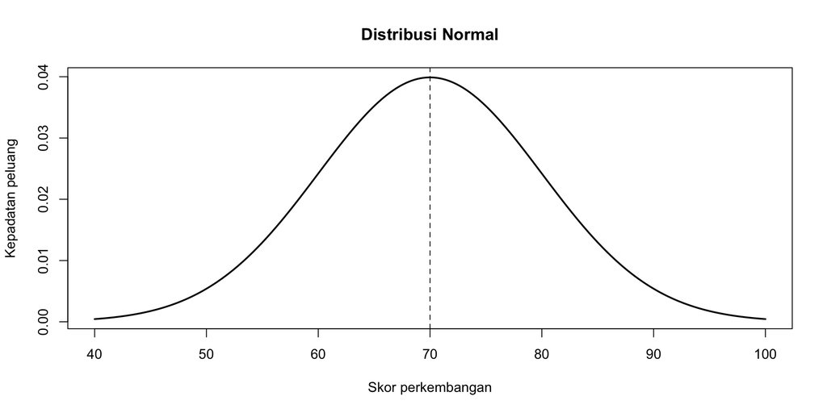

Kurva normal memiliki luas total sebesar 1.

Luas di bawah kurva pada suatu interval menunjukkan peluang bahwa variabel acak berada pada interval tersebut.

## Distribusi Normal dan Aturan Empiris

Pada distribusi normal, terdapat aturan empiris:

| Interval | Proporsi Data |
| --- | --- |
| $\mu \pm 1\sigma$ | Sekitar 68% |
| $\mu \pm 2\sigma$ | Sekitar 95% |
| $\mu \pm 3\sigma$ | Sekitar 99,7% |

Contoh:

Skor perkembangan bahasa anak memiliki rata-rata 70 dan simpangan baku 10.

Sekitar 68% skor diperkirakan berada pada interval:

$$70\pm 10$$

$$60\leq X\leq 80$$

Sekitar 95% skor diperkirakan berada pada interval:

$$50\leq X\leq 90$$

Aturan ini berlaku sebagai pendekatan untuk distribusi yang mendekati normal.

## Distribusi Normal Baku

Distribusi normal baku memiliki:

$$\mu=0$$

$$\sigma=1$$

Transformasi dari variabel normal menjadi normal baku dilakukan menggunakan skor $Z$:

$$Z=\frac{X-\mu}{\sigma}$$

Skor $Z$ menyatakan jarak suatu nilai dari rata-rata dalam satuan simpangan baku.

Interpretasi:

- $Z=0$: nilai berada tepat pada rata-rata.
- $Z=1$: nilai berada satu simpangan baku di atas rata-rata.
- $Z=-1$: nilai berada satu simpangan baku di bawah rata-rata.

## Contoh Menghitung Skor Z

Skor perkembangan bahasa anak memiliki:

$$\mu=70,\quad \sigma=10$$

Seorang anak memperoleh skor 85.

Skor Z:

$$Z=\frac{85-70}{10}$$

$$Z=1.5$$

Artinya, skor anak tersebut berada 1,5 simpangan baku di atas rata-rata kelompok.

Skor Z membantu membandingkan posisi relatif suatu nilai terhadap distribusinya.

## Menghitung Peluang dengan Distribusi Normal

Misalkan:

$$X\sim N(70,10^2)$$

Ditanyakan peluang seorang anak memperoleh skor kurang dari 85.

Transformasi menjadi skor Z:

$$Z=\frac{85-70}{10}=1.5$$

Sehingga:

$$P(X<85)=P(Z<1.5)$$

Berdasarkan distribusi normal baku:

$$P(Z<1.5)\approx 0.9332$$

Jadi, peluang seorang anak memperoleh skor kurang dari 85 adalah sekitar 93,32%.

## Distribusi Binomial

Distribusi binomial digunakan untuk menghitung peluang banyaknya keberhasilan dalam sejumlah percobaan yang memiliki dua kemungkinan hasil.

Syarat distribusi binomial:

- Jumlah percobaan tetap, yaitu $n$.
- Setiap percobaan memiliki dua kemungkinan hasil.
- Peluang keberhasilan $p$ tetap.
- Percobaan saling independen.

Distribusi binomial dinotasikan:

$$X\sim Bin(n,p)$$

Rumus peluang:

$$P(X=x)=
\binom{n}{x}p^x(1-p)^{n-x}$$

dengan:

$$\binom{n}{x}=\frac{n!}{x!(n-x)!}$$

## Contoh Distribusi Binomial

Seorang guru mengamati lima anak yang mengikuti kegiatan menyusun balok.

Peluang setiap anak berhasil menyelesaikan tugas adalah 0,6.

Misalkan:

$$X=\text{jumlah anak yang berhasil}$$

Dengan asumsi percobaan independen:

$$X\sim Bin(5,0.6)$$

Ditanyakan peluang tepat tiga anak berhasil.

$$P(X=3)=
\binom{5}{3}(0.6)^3(0.4)^2$$

$$P(X=3)=10(0.216)(0.16)$$

$$P(X=3)=0.3456$$

Jadi, peluang tepat tiga anak berhasil menyelesaikan tugas adalah 34,56%.

## Mean dan Varians Distribusi Binomial

Untuk variabel acak binomial:

$$X\sim Bin(n,p)$$

Nilai harapan:

$$E(X)=np$$

Varians:

$$Var(X)=np(1-p)$$

Simpangan baku:

$$SD(X)=\sqrt{np(1-p)}$$

Pada contoh sebelumnya:

$$E(X)=5(0.6)=3$$

$$Var(X)=5(0.6)(0.4)=1.2$$

$$SD(X)=\sqrt{1.2}\approx 1.095$$

Dalam jangka panjang, rata-rata jumlah anak yang berhasil diperkirakan sebesar tiga anak dari lima anak.

## Perbandingan Distribusi Binomial dan Normal

| Karakteristik | Binomial | Normal |
| --- | --- | --- |
| Jenis variabel | Diskrit | Kontinu |
| Bentuk | Nilai terpisah | Kurva kontinu |
| Parameter | $n$ dan $p$ | $\mu$ dan $\sigma$ |
| Contoh | Jumlah anak berhasil | Skor perkembangan |
| Penggunaan | Menghitung peluang keberhasilan | Menghitung peluang pada interval |

Distribusi normal dapat digunakan sebagai pendekatan terhadap distribusi binomial apabila jumlah percobaan cukup besar dan distribusi binomial tidak terlalu menceng.

Salah satu aturan praktis:

$$np\geq 5$$

$$n(1-p)\geq 5$$

Untuk pendekatan yang lebih baik, beberapa referensi menggunakan batas yang lebih ketat.

## Latihan Kontekstual

Seorang guru PIAUD mengamati 10 anak yang mengikuti kegiatan motorik halus.

Peluang seorang anak berhasil menyelesaikan tugas adalah 0,7.

Misalkan $X$ menyatakan jumlah anak yang berhasil.

Jawablah pertanyaan berikut:

- Tentukan distribusi peluang yang sesuai.
- Hitung peluang tepat 7 anak berhasil.
- Hitung nilai harapan jumlah anak yang berhasil.
- Hitung varians dan simpangan baku.
- Jelaskan makna nilai harapan dalam konteks pengamatan.

Gunakan rumus distribusi binomial.

## Refleksi Pembelajaran

Peluang membantu kita memahami ketidakpastian dalam pengamatan pendidikan.

Distribusi peluang memberikan model matematis untuk menggambarkan kemungkinan nilai suatu variabel acak.

Konsep-konsep tersebut menjadi dasar untuk memahami statistika inferensial, termasuk:

- Estimasi parameter.
- Pengujian hipotesis.
- Interval kepercayaan.
- Analisis hubungan antarvariabel.
- Pemodelan statistik dalam penelitian pendidikan.

**Pertanyaan refleksi:**

Bagaimana konsep peluang dapat membantu guru PIAUD membuat keputusan yang lebih baik berdasarkan hasil pengamatan perkembangan anak?